# Stock Price Forecasting

Author

Julius Mondschein

# Purpose:

Stock price prediction using historical data, I develop a predictive model to forecast the stock prices based on the historical market data. Based on the historical trends of the high, low, open, close and volume of a stock and its historical volatility and moving averages, we attempt to find out the patterns in the historical trends of a stock in order to predict the future trends in the stock. Using the machine learning techniques, we attempt to predict the accuracy of the model based on the historical data provided and we try to predict the accuracy of our model in terms of forecasting the next day’s closing price of the stock and give a comprehensive view about the model that we have developed.

# Alpaca Market API, Stock Prediction

```python
import os
import pandas as pd
import numpy as np
import matplotlib.pyplot as plt
from datetime import datetime

from alpaca.data.historical import StockHistoricalDataClient
from alpaca.data.requests import StockBarsRequest
from alpaca.data.timeframe import TimeFrame
from sklearn.metrics import mean_absolute_error

from sklearn.ensemble import RandomForestRegressor
from sklearn.model_selection import train_test_split
from sklearn.metrics import mean_squared_error
```

```python
SYMBOL = "AAPL"
START_DATE = "2023-01-01"
END_DATE = datetime.today().strftime("%Y-%m-%d")
client = StockHistoricalDataClient("PKMHUX5TXYAFWCSX6GTZC3NLEL",  "5mDe8bx2qEx2AQ7p7PxkKicewWYi1YG5Px1h6sR8xGXs")

request_params = StockBarsRequest(
    symbol_or_symbols=SYMBOL,
    start=START_DATE,
    end=END_DATE,
    timeframe=TimeFrame.Day
)

bars = client.get_stock_bars(request_params)
df = bars.df.reset_index()

df = df[["timestamp", "open", "high", "low", "close", "volume"]]

df["returns"] = df["close"].pct_change()
df["volatility"] = df["returns"].rolling(window=5).std()
df["ma_5"] = df["close"].rolling(window=5).mean()
df["ma_10"] = df["close"].rolling(window=10).mean()
df["ma_20"] = df["close"].rolling(window=20).mean()

df["target"] = df["close"].shift(-1)
df = df.dropna()

features = ["close", "volume", "volatility", "ma_5", "ma_10", "ma_20"]

X = df[features]
y = df["target"]

X_train, X_test, y_train, y_test = train_test_split(X, y, test_size=0.2, random_state=42)

model = RandomForestRegressor(n_estimators=300, max_depth=10, random_state=42)
model.fit(X_train, y_train)

y_pred = model.predict(X_test)
mae = mean_absolute_error(y_test, y_pred)
print(f"Mean Absolute Error: ${mae:.2f}")
```

```
Mean Absolute Error: $2.86
```

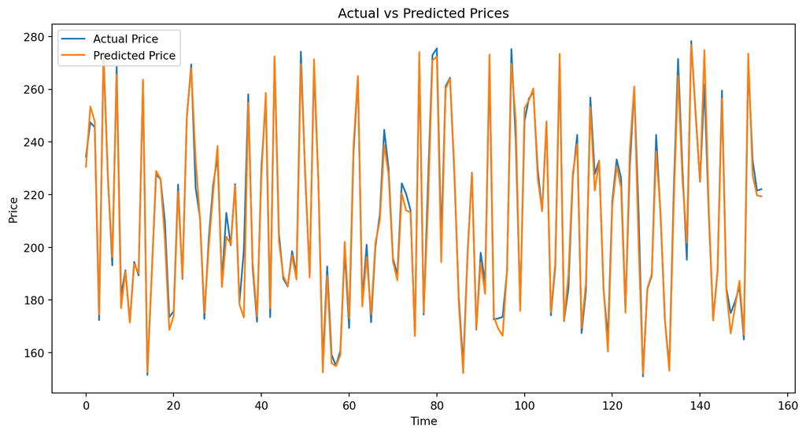

```
Next Dayn Price For Apple: $264.50
```

```python
plt.figure(figsize=(12, 6))
plt.plot(y_test.values, label="Actual Price")
plt.plot(y_pred, label="Predicted Price")
plt.title("Actual vs Predicted Prices")
plt.xlabel("Time")
plt.ylabel("Price")
plt.legend()
plt.show()

latest_data = X.iloc[-1:].values
latest_prediction = model.predict(latest_data)[0]
print(f"Next Dayn Price For Apple: ${latest_prediction:.2f}")
```

There are small residual deviations at certain peaks and troughs, which is a common behaviour for tree based ensemble models. The price smoothing seen in the RF regressor is due to the averaging over the many decision trees, which can tend to average out or dampen outliers. This tends to eliminate sharp price spikes or drops. Apart from the deviations at peaks and troughs, the RF alignment looks to have low bias and appropriate control of variance, especially with max_depth set to 10 in order to limit overfitting.

# Prophet API Stock Prediction

Time series forecasting with the Prophet model After demonstrating the Random Forest approach to forecasting after engineering a range of time-related features, we will also demonstrate an approach using the Prophet model, which is a type of time-series forecasting model. The Random Forest model relied on engineered features such as moving averages and volatility, but in this case we will use the Prophet model to model the time directly, by decomposing the time series into trend and seasonal components.

```python
from prophet import Prophet
import matplotlib.pyplot as plt
import pandas as pd


price_data = df[["timestamp", "close"]].copy()
price_data = price_data.rename(columns={"timestamp": "ds", "close": "y"})
price_data["ds"] = pd.to_datetime(price_data["ds"]).dt.tz_localize(None)
```

```python
m = Prophet(
    daily_seasonality=False,
    weekly_seasonality=True,
    yearly_seasonality=True,
    changepoint_prior_scale=0.05
)
m.fit(price_data)


future = m.make_future_dataframe(periods=30)
forecast = m.predict(future)


tomorrow = forecast[forecast["ds"] > price_data["ds"].max()].iloc[0]
tomorrow_date = tomorrow["ds"].strftime("%Y-%m-%d")
tomorrow_price = tomorrow["yhat"]
```

```
21:32:31 - cmdstanpy - INFO - Chain [1] start processing
21:32:31 - cmdstanpy - INFO - Chain [1] done processing
```

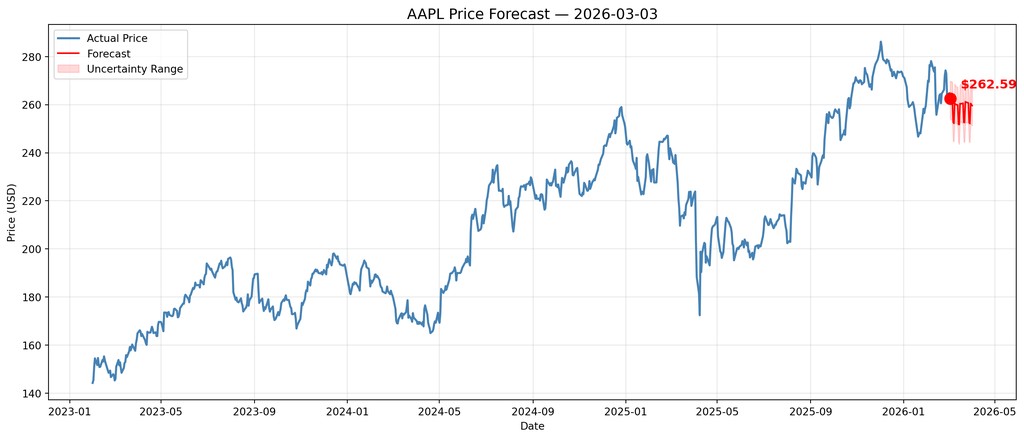

```python
fig, ax = plt.subplots(figsize=(14, 6))

ax.plot(price_data["ds"], price_data["y"], color="steelblue", linewidth=2, label="Actual Price")

future_only = forecast[forecast["ds"] > price_data["ds"].max()]
ax.plot(future_only["ds"], future_only["yhat"], color="red", label="Forecast")
ax.fill_between(future_only["ds"], future_only["yhat_lower"], future_only["yhat_upper"],
                color="red", alpha=0.15, label="Uncertainty Range")

ax.scatter(tomorrow["ds"], tomorrow_price, color="red", s=120, zorder=5)
ax.annotate(f"${tomorrow_price:.2f}", xy=(tomorrow["ds"], tomorrow_price),
            xytext=(10, 10), textcoords="offset points",
            fontsize=12, color="red", fontweight="bold")

ax.set_title(f"{SYMBOL} Price Forecast — {tomorrow_date}", fontsize=14)
ax.set_xlabel("Date")
ax.set_ylabel("Price (USD)")
ax.legend()
ax.grid(True, alpha=0.3)
plt.tight_layout()
plt.show()
```

Weekly and yearly seasonality are included in the model, while daily seasonality is excluded. The changepoint_prior_scale parameter is set to 0.05 to prevent overfitting, or excessive changes in the trend.

```python
print(f"Predicted close for {tomorrow_date}: ${tomorrow_price:.2f}")
print(f"Range: ${tomorrow['yhat_lower']:.2f} – ${tomorrow['yhat_upper']:.2f}")
```

```
Predicted close for 2026-03-03: $262.59
Range: $254.65 – $269.76
```

The forecast visualization shows the historic prices along with the forecast and its confidence interval. The shaded area of the uncertainty band represents the range of forecast values, accounting for potential level shifts and seasonal components. Prophet provides a probabilistic and decomposed forecast accounting for temporal and seasonal components in the data.

# Montecarlo Simulation

This section implements a Monte Carlo simulation on top of the Prophet model to quantify forecast uncertainty beyond the built-in confidence intervals.

Instead of relying on a single fitted model, the code runs 100 simulations. In each iteration, Gaussian noise with a mean of 0 and a standard deviation of 1% is multiplicatively applied to the historical closing prices.

```python
predictions = []
for i in range(100):
    noise = price_data.copy()
    noise["y"] = noise["y"] * (1 + np.random.normal(0, 0.01, len(noise)))
    m_sim = Prophet(daily_seasonality=False, weekly_seasonality=True, yearly_seasonality=True)
    m_sim.fit(noise)
    fc_sim = m_sim.predict(m_sim.make_future_dataframe(periods=30))
    predictions.append(fc_sim[fc_sim["ds"] > price_data["ds"].max()].iloc[0]["yhat"])

print(f"Mean: ${np.mean(predictions):.2f}")
print(f"Std Dev: ${np.std(predictions):.2f}")
print(f"Range: ${np.min(predictions):.2f} – ${np.max(predictions):.2f}")
```

[output not shown]

[output cut: 145 more lines]

[output not shown]

```
Mean: $263.68
Std Dev: $0.78
Range: $260.87 – $265.33
```

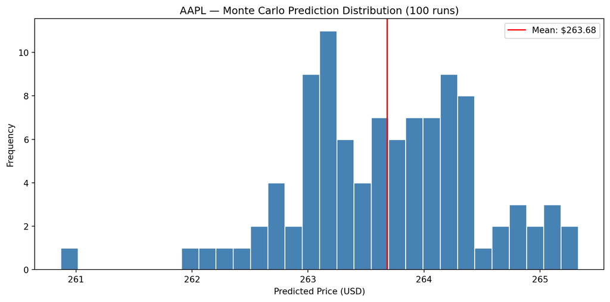

```python
plt.figure(figsize=(10, 5))
plt.hist(predictions, bins=30, color="steelblue", edgecolor="white")
plt.axvline(np.mean(predictions), color="red", label=f"Mean: ${np.mean(predictions):.2f}")
plt.title(f"{SYMBOL} — Monte Carlo Prediction Distribution (100 runs)")
plt.xlabel("Predicted Price (USD)")
plt.ylabel("Frequency")
plt.legend()
plt.tight_layout()
plt.show()
```

A short recap of the distribution of our simulated forecasts: here is the histogram of our set of simulations with the corresponding red vertical line representing the mean. We observe that the standard deviation of this distribution is relatively low. This means that the model has a stable behaviour when we introduce small variations on the historical prices in the input data. In other words, the impact of small perturbations is not strong on the final forecast.

This method is technically a “perturbation method” where we model parameter and data uncertainty by repeatedly refitting the model to stochastic variations of the data. The intuition is that this provides a more empirical, rather than theoretical, measure of the forecast uncertainty and in practice the analytical uncertainty of Prophet is often found not to be particularly reliable in this context.

# Future Ideas

1. Experiment with different machine learning models (e.g., LSTM, XGBoost) for stock price prediction.
2. Incorporate additional features such as news sentiment analysis, social media trends, and macroeconomic indicators.
3. Implement a backtesting framework to evaluate the performance of the trading strategy over historical data.
4. Explore the use of reinforcement learning for dynamic portfolio management.
5. Investigate the impact of trading volume and order book data on price movements.
6. Stress test the models under different market conditions to evaluate robustness.
7. Stress test the models with extreme market events (e.g., flash crashes, economic shocks) to assess their performance.